# Statistical Modeling Basics

## Modeling

After all that we've gone through at this point, modeling will be the easy part for you.

The biggest hurdle in statistical enterprise is almost always obtaining and preparing the data.

The better you are at programming:

- the faster you will do things
- the more you can explore
- the more you can spend time learning other things (like new modeling techniques/packages)

With R, you now have thousands of packages to choose from for modeling.

## Modeling

The standard format for regression modeling can serve as baseline code for modeling in other packages.

Most take a formula and data argument. Formula is actually a class of object.

- a regression of y on x and z

```r
lm(y ~ x + z, data=myData)
```

Some might take matrix/vector arguments.

```r
lm.fit(X, y)          # lm.fit is the workhorse of lm
```

Unsupervised methods usually will need a matrix argument.

- sometimes a dataframe is ok

```r
princomp(X)
```

## Modeling

There are variations on those basic themes (below)

However the previous examples constitute the vast majority of standard and complex models.

In addition, they all come with additional arguments that you'll need to familiarize yourself with before using the function.

```r
glm(art ~ ., data=bioChemists, family = 'poisson')    # number of articles predicted by everything else

library(pscl)
hurdle(art ~ ., data=bioChemists, dist = 'poisson', zero.dist = "binomial")   # to deal with excess zeros
```

```r
library(lme4)
lmer(Reaction ~ Days + (1|Subject), data=sleepstudy)  # a mixed model with a random intercept for Subject
```

```r
library(mgcv)
gam(accel ~ s(times), data=mcycle)                    # generalized additive model
```

## Modeling Results

The following is a very typical way you would go about things with data ready.

1. Create a model object.
2. Use a summary or similar print function to see the results.
3. Use other package/function specific functionality on the model object.
4. Extract parts of the model object for your own exploration.

## Model Example

Standard regression.

```r
myModel = lm(y ~ x1 + x2)
summary(myModel)
```

```
##
## Call:
## lm(formula = y ~ x1 + x2)
##
## Residuals:
##      Min       1Q   Median       3Q      Max
## -2.36509 -0.61027 -0.05682  0.62988  2.04070
##
## Coefficients:
##             Estimate Std. Error t value Pr(>|t|)
## (Intercept)  0.05794    0.09674   0.599 0.550636
## x1           0.84359    0.10538   8.005 2.62e-12 ***
## x2           0.38497    0.09522   4.043 0.000106 ***
## ---
## Signif. codes:  0 '***' 0.001 '**' 0.01 '*' 0.05 '.' 0.1 ' ' 1
##
## Residual standard error: 0.9653 on 97 degrees of freedom
## Multiple R-squared:  0.5003, Adjusted R-squared:   0.49
## F-statistic: 48.56 on 2 and 97 DF,  p-value: 2.443e-15
```

## Model Example

Plot of a generalized additive model object.

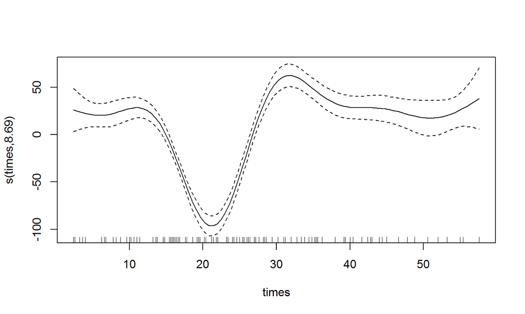

```r
myModel = gam(accel ~ s(times), data=mcycle)
plot(myModel)
```

## Modeling

Do a search for a model that you would like to learn more about.

If it's a somewhat standard model try an R search

```r
??`generalized linear model`
```

For something you're less sure about you might try several approaches:

- General web search of model name with R attached (best approach)
- Use Rseek (a more sophisticated search/results)
- [RDocumentation.org](http://www.rdocumentation.org/) and search 'all fields' or 'description' with the model name.
- RSiteSearch function
  - generally poor results in my experience
- You can also ask us to help narrow your search to maybe some popular implementations.

## Modeling

Once you find a package that has something you want to try, take the following steps.

- Install the package
- Note that many packages are now on Github and might require different means for installation
- *Consult the manual*
  - Cannot be stressed enough
- In the manual find one or two primary functions
- Read the helpfile, run the example code when finished (if available; you don't have to copy and paste)

```r
example('modelingFunctionName')
```

## Modeling

Otherwise you will:

- not know which functions might be most useful
- get errors when you try to run it with your own data
- miss out on neat features of the function
- miss out on other related functions (e.g. visualization, diagnostics)

Think of one or two models you're interested in and try this for yourself.

We'll come around and help you try and implement their examples if you have trouble or answer other questions.

## Other

Optimization problems

- Start with optim function
  - Just know there are other versions of it that provide nicer output and other features.
- Cran task view on optimization

Simulation

- practically every probability distribution under the sun is found in R
- Some example packages to supplement base R: vgam, gamlss
- Cran task view on probability distributions